# Chapter 2 practice exercises

## 3

This is a continuation of the analysis of data on breakfast cereals. The following are the diagnostic plots we discussed in Chapter 1.

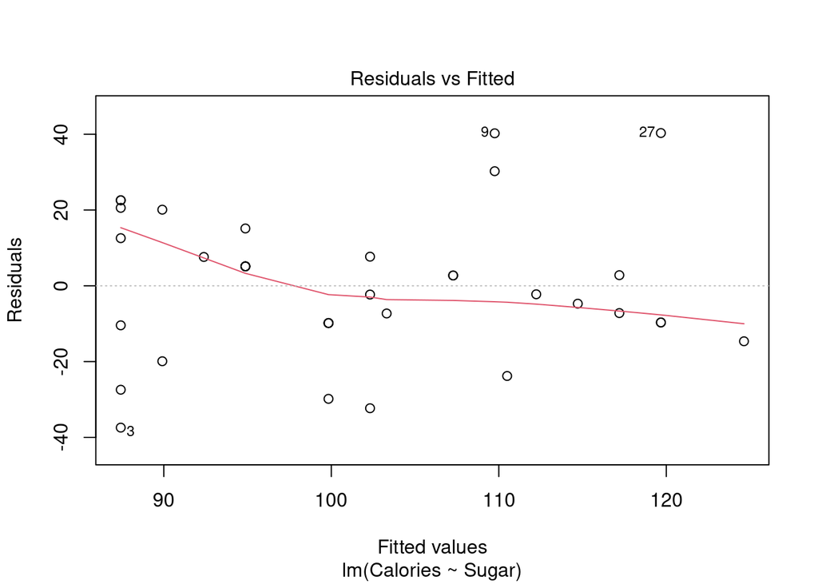

```r
plot(ff,which=1)
```

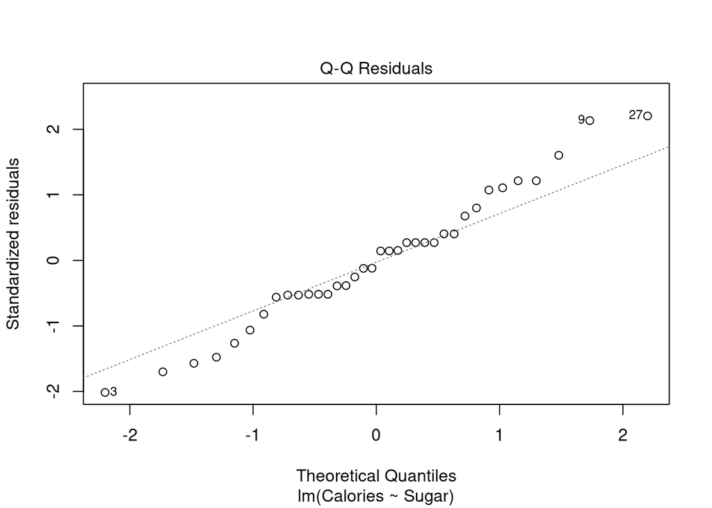

```r
plot(ff,which=2)
```

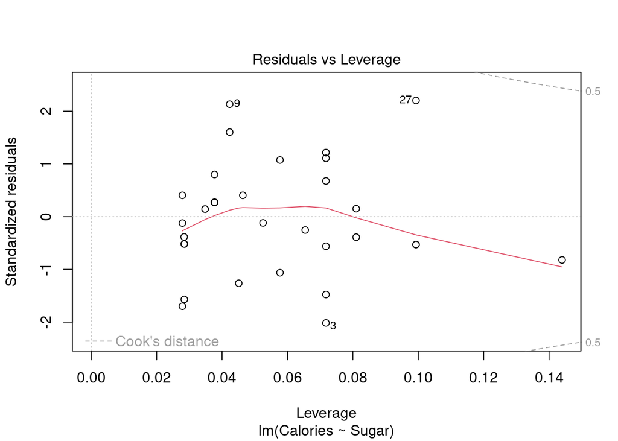

```r
plot(ff,which=5)
```

1. Comment on the linear model assumption. Which of the three plots do you use for this?

   **Residuals vs Fitted plot. The data appears to be fairly linear, there is a slight down tick in the line.**
2. Comment on the assumption of constant error SD. Which of the three plots do you use for this?

   **Residuals vs Fitted plot. The assumption of constant error SD seems to be met as the points are randomly scattered around residual=0 and appear to be evenly spread.**
3. Comment on the assumption that the errors are normally distributed. Which of the three plots do you use for this?

   **Q-Q plot. There appears to be something going on with the points at the very left (all points below line) and very right (all points above line) of the plot which could suggest errors with a non-normal distribution.**
4. Do any of the cereals have leverage that stands out from the rest? Which of the three plots do you use for this?

   **Residuals vs Leverage plot. The point furthest to right does appear to have greater leverage than the other points.**
5. Do any of the cereals have noteworthy influence, as measured by the Cook’s distance. Use our rule-of-thumb from the Chapter 1 notes.

   **Residuals vs Leverage plot. No, none of the points have noteworthy influence (i.e. Cook’s distance > 1)**

## 4

This is a continuation of the analysis of data on breakfast cereals. Recall from the Chapter 1 exercises that Mueslix has 13 grams of sugar.

1. Calculate a 95% **confidence** interval for the mean calories of cereals with 13 grams of sugar. Interpret this interval.

   **We are 95% confident that the average calories for Cereals with 13 g of sugar is between 107.3 and 132.0 calories.**
2. Calculate a 95% **prediction** interval for the mean calories of cereals with 13 grams of sugar. Interpret this interval.

   **We expect about 95% of future cereals with 13 g of sugar to contain between 78.6 and 160.7 calories.**

(Hint: See the chapter 2 R demo.)

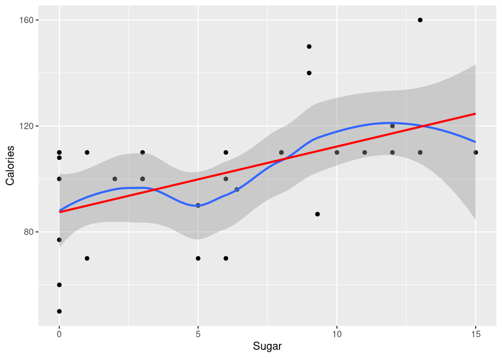

```r
data("Cereal")
ggplot(Cereal, aes(x=Sugar, y=Calories)) +
  geom_point() + geom_smooth() +
  geom_smooth(method="lm", se=FALSE, color="red")
```

```r
model <- lm(Calories ~ Sugar, data=Cereal)
model
```

```
##
## Call:
## lm(formula = Calories ~ Sugar, data = Cereal)
##
## Coefficients:
## (Intercept)        Sugar
##      87.428        2.481
```

```r
newCereal <- data.frame(Sugar = 13)
predict(model,newdata=newCereal,interval = "confidence",level=0.95)
```

```
##        fit      lwr    upr
## 1 119.6783 107.3365 132.02
```

```r
predict(model,newdata=newCereal,interval = "prediction",level=0.95)
```

```
##        fit      lwr      upr
## 1 119.6783 78.61687 160.7396
```

## 5

Data on 116 Savannah sparrows includes measurements of weight and wing length. A scatterplot with smooth and least squares regression line is shown below.

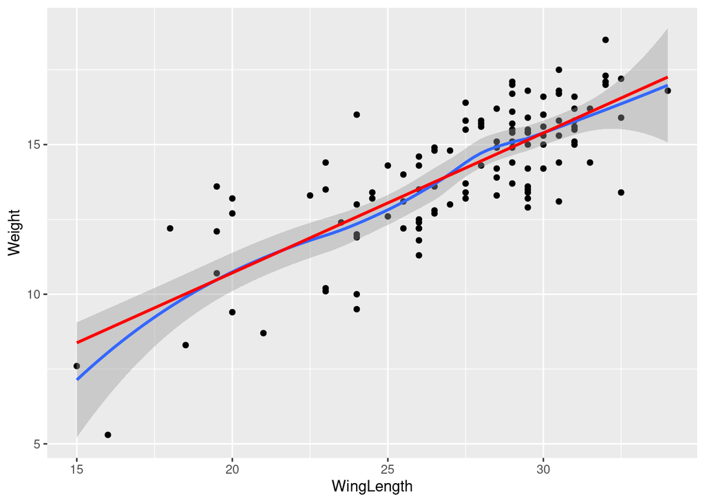

```r
data("Sparrows")
ggplot(Sparrows,aes(x=WingLength,y=Weight)) +
  geom_point() +  geom_smooth() +
  geom_smooth(method="lm",se=FALSE, color="red")
```

```r
model2 <- lm(Weight ~ WingLength, data = Sparrows)
summary(model2)$coefficients
```

```
##             Estimate Std. Error   t value     Pr(>|t|)
## (Intercept) 1.365490 0.95730874  1.426384 1.564905e-01
## WingLength  0.467404 0.03471756 13.463042 2.621940e-25
```

```r
confint(model2, parm = "WingLength", level = 0.95)
```

```
##                2.5 %    97.5 %
## WingLength 0.3986288 0.5361792
```

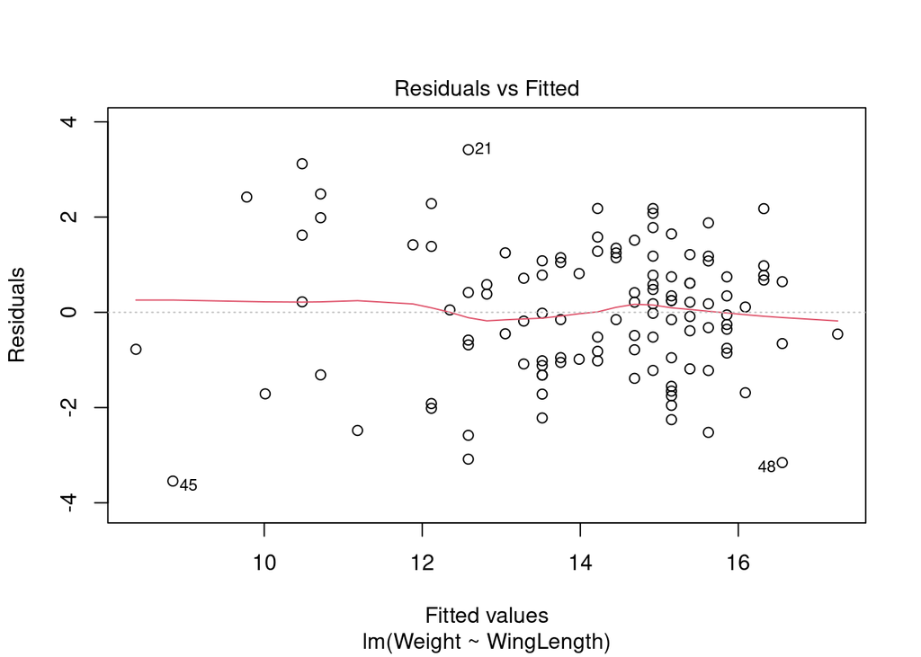

```r
plot(model2, which = 1)
```

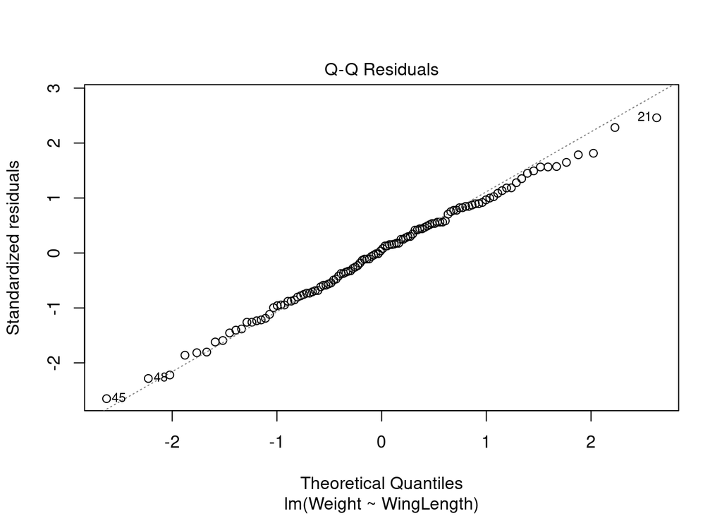

```r
plot(model2, which = 2)
```

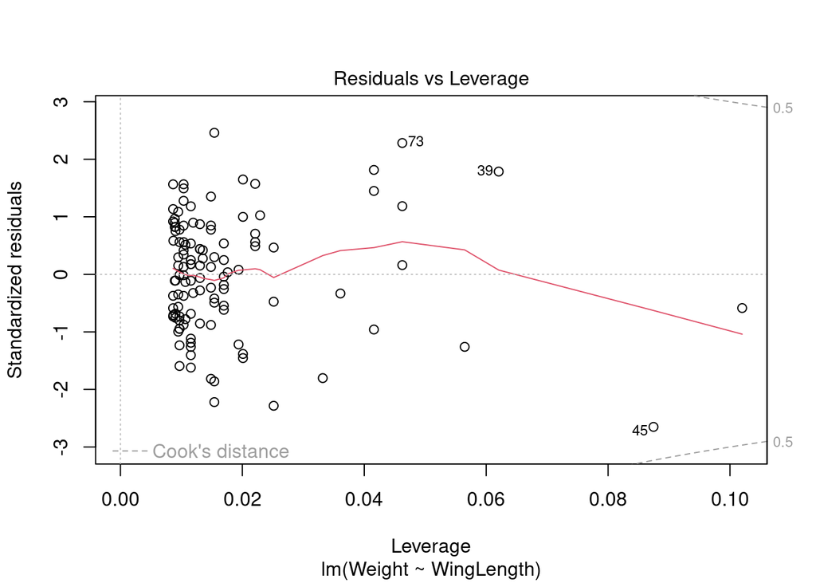

```r
plot(model2, which = 5)
```

1. Test the hypothesis that wing length has a linear relationship with weight. Report the hypotheses, test statistics, P-value and your conclusion.
   - **null hypothesis: there is no association between wing length and weight**
   - **alternative hypothesis: there is an association between wing length and weight**
   - **test statistic is the t-value = 13.46, p-value = 2.62e-25**
   - **conclusion: there is very strong evidence of a linear association**
2. Find and interpret a 95% confidence interval for the slope of this regression model.

   **We are 95% confident that the slope of the fitted regression line is between 0.399 and 0.536.**
3. Comment on the linear model assumption.

   **Based on the Residuals vs Fitted plot the data appears linear. There is a slight bump in the line but nothing major.**
4. Comment on the assumption of constant error SD.

   **Based on the Residuals vs Fitted plot the points appear to be pretty randomly situated and spread across residual = 0.**
5. Comment on the assumption that the errors are normally distributed.

   **Based on the Q-Q plot the ends of the distribution appear to not fit perfectly (points above line on the very left, points below line on the very right), this could indicate a non-normal distribution. But the seem to fit quite close to the line so it may not be an issue.**
6. Do any of the sparrows have noteworthy influence, as measured by the Cook’s distance. Use our rule-of-thumb from the Chapter 1 supplement notes.

   **No, none of the sparrows have noteworthy influence (Cook’s distance > 1)**

## 6

Type `help("SpeciesArea")` into the R console to read about the dataset on islands in Southeast Asia. The following R code examines the relationship between the area and number of mammal species on the islands, both on the log-10 scale.

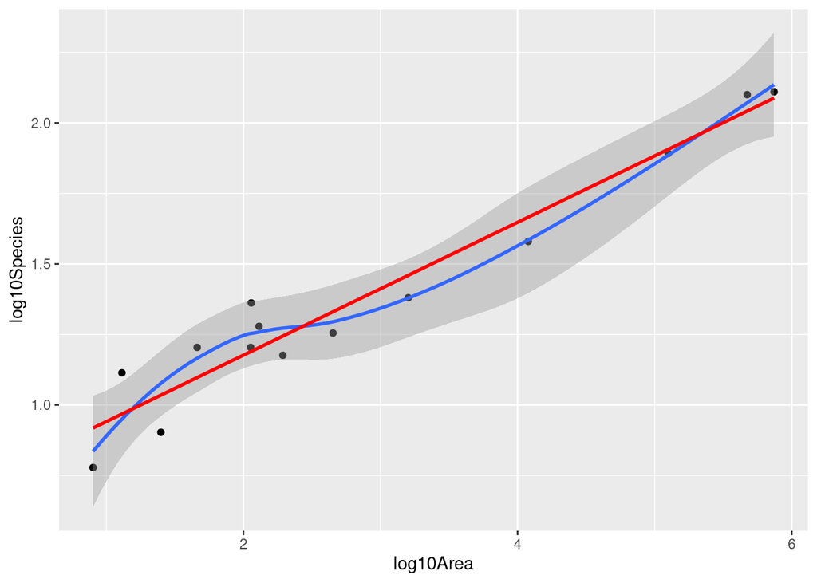

```r
data("SpeciesArea")
SpeciesArea <- mutate(SpeciesArea,
                      log10Area = log10(Area),log10Species=log10(Species))
ggplot(SpeciesArea,aes(x=log10Area,y=log10Species)) +
  geom_point() +  geom_smooth() +
  geom_smooth(method="lm",se=FALSE, color="red")
```

```r
model3 <- lm(log10Species ~ log10Area, data = SpeciesArea)
summary(model3)
```

```
##
## Call:
## lm(formula = log10Species ~ log10Area, data = SpeciesArea)
##
## Residuals:
##       Min        1Q    Median        3Q       Max
## -0.140191 -0.078480  0.000344  0.071032  0.171692
##
## Coefficients:
##             Estimate Std. Error t value Pr(>|t|)
## (Intercept)  0.70569    0.05757   12.26 3.81e-08 ***
## log10Area    0.23547    0.01750   13.46 1.34e-08 ***
## ---
## Signif. codes:  0 '***' 0.001 '**' 0.01 '*' 0.05 '.' 0.1 ' ' 1
##
## Residual standard error: 0.1054 on 12 degrees of freedom
## Multiple R-squared:  0.9379, Adjusted R-squared:  0.9327
## F-statistic: 181.1 on 1 and 12 DF,  p-value: 1.335e-08
```

```r
confint(model3)
```

```
##                 2.5 %    97.5 %
## (Intercept) 0.5802605 0.8311140
## log10Area   0.1973499 0.2735991
```

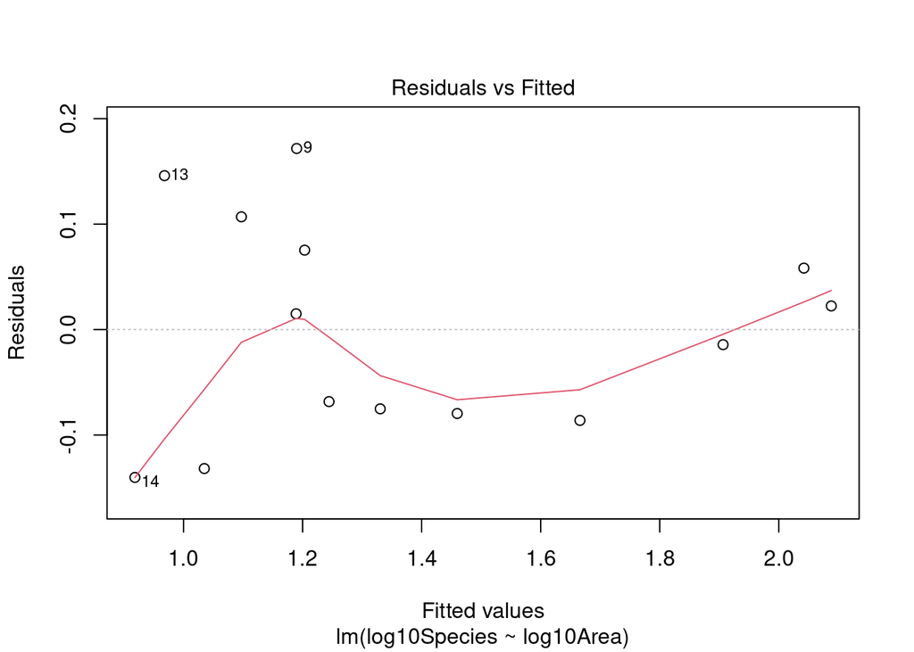

```r
plot(model3, which = 1)
```

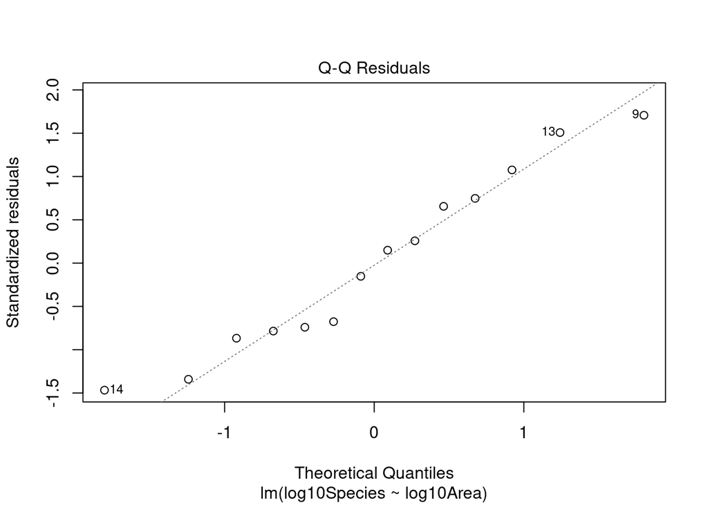

```r
plot(model3, which = 2)
```

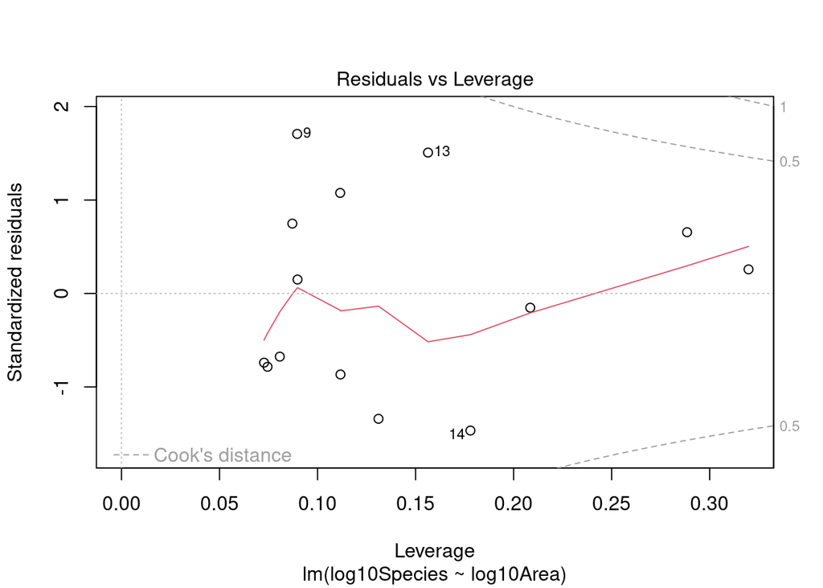

```r
plot(model3, which = 5)
```

1. Test the hypothesis that log-10-area has a linear relationship with log-10-species. Report the hypotheses, test statistics, P-value and your conclusion.
   - **null hypothesis: there is no association between the area of an island and the number of species found on the island.**
   - **alternative hypothesis: there is an association between the area of an island and the number of species found on the island.**
   - **test statistic is the t-value = 13.46, p-value = 1.34e-08**
   - **conclusion: there is very strong evidence of a linear association**
2. Find and interpret a 95% confidence interval for the slope of this regression model.

   **We are 95% confident that the slope of the fitted regression line is between 0.197 and 0.274.**
3. Comment on the linear model assumption.

   **Based on the Residuals vs Fitted plot the relationship may not be linear, the line seen on the plot has several “bumps” which may indicated a larger order polynomial model should be used.**
4. Comment on the assumption of constant error SD.

   **Based on the Q-Q plot the errors do appear to be normally distributed as they follow the line quite well.**
6. Do any of the sparrows have noteworthy influence, as measured by the Cook’s distance. Use our rule-of-thumb from the Chapter 1 supplement notes.

   **No, none of the islands have noteworthy influence (Cook’s distance > 1)**